# Getting stated with `EpiAware`

This tutorial introduces the basic functionality of `EpiAware`. `EpiAware` is a package for making inferences on epidemiological case/determined infection data using a model-based approach.

## `EpiAware` models

The models we consider are discrete-time $t = 1,\dots, T$ with a latent random process, $Z_t$ generating stochasticity in the number of new infections $I_t$ at each time step. Observations are treated as downstream random variables determined by the actual infections and a model of infection to observation delay.

#### Mathematical definition

$$\begin{align} Z_\cdot &\sim \mathcal{P}(\mathbb{R}^T) | \theta_Z, \\ I_0 &\sim f_0(\theta_I), \\ I_t &\sim g_I(\{I_s, Z_s\}_{s < t}, \theta_{I}), \\ y_t &\sim f_O(\{I_s\}_{s \leq t}, \theta_{O}). \end{align}$$

Where, $\mathcal{P}(\mathbb{R}^T) | \theta_Z$ is a parametric process on $\mathbb{R}^T$. $f_0$ and $f_O$ are parametric distributions on, respectively, the initial number of infections and the observed case data conditional on underlying infections. $g_I$ is distribution of new infections conditional on infections and latent process in the past. Note that we assume that new infections are conditional on the strict past, whereas new observations can depend on infections on the same time step.

#### Code structure outline

An `EpiAware` model in code is created from three modular components:

- A `LatentModel`: This defines the model for $Z_\cdot$. This chooses $\mathcal{P}(\mathbb{R}^T) | \theta_Z$.
- An `EpiModel`: This defines a generative process for infections conditional on the latent process. This chooses $f_0(\theta_I)$, and $g_I(\{I_s, Z_s\}_{s < t}, \theta_{I})$.
- An `ObservationModel`: This defines the observation model. This chooses $f_O({I_s}_{s \leq t}, \theta_{O})$

#### Reproductive number

`EpiAware` models do not need to specify a time-varying reproductive number $\mathcal{R}_t$ to generate $I_\cdot$, however, this is often a quantity of interest. When not directly used we will typically back-calculate $\mathcal{R}_t$ from the generated infections:

$$\mathcal{R}_t = {I_t \over \sum_{s \geq 1} g_s I_{t-s} }.$$

Where $g_s$ is a discrete generation interval. For this reason, even when not using a reproductive number approach directly, we ask for a generation interval.

```julia
begin
    using EpiAware
    using Turing
    using Distributions
    using StatsPlots
    using Random
    using DynamicPPL
    using Statistics
    using DataFramesMeta
    using LinearAlgebra
end
```

## Random walk `LatentModel`

As an example, we choose the latent process as a random walk with parameters $\theta_Z$:

- $Z_0$: Initial position.
- $\sigma^2_{Z}$: The step-size variance.

Conditional on the parameters the random walk is then generated by white noise:

$$\begin{align} Z_t &= Z_0 + \sigma_{RW} \sum_{t= 1}^T \epsilon_t, \\ \epsilon_t &\sim \mathcal{N}(0,1). \end{align}$$

In `EpiAware` we provide a constructor for random walk latent models with priors for $\theta_Z$. We choose priors,

```julia
rwp = EpiAware.RandomWalk(Normal(),
    truncated(Normal(0.0, 0.02), 0.0, Inf))
```

```
RandomWalk{Normal{Float64}, Truncated{Normal{Float64}, Continuous, Float64, Float64, Float64}}(Distributions.Normal{Float64}(μ=0.0, σ=1.0), Truncated(Distributions.Normal{Float64}(μ=0.0, σ=0.02); lower=0.0, upper=Inf))
```

## Direct infection `EpiModel`

This is a simple model where the unobserved log-infections are directly generated by the latent process $Z$.

$$\log I_t = \log I_0 + Z_t.$$

As discussed above, we still ask for a defined generation interval, which can be used to calculate $\mathcal{R}_t$.

```julia
truth_GI = Gamma(2, 5)
```

```
Distributions.Gamma{Float64}(α=2.0, θ=5.0)
```

The `EpiData` constructor performs double interval censoring to convert our *continuous* estimate of the generation interval into a discretized version. We also implement right truncation using the keyword `D_gen`.

```julia
model_data = EpiData(truth_GI, D_gen = 10.0)
```

```
EpiData{Float64, typeof(exp)}([0.056722565637507084, 0.0944813112842689, 0.11668723746973605, 0.12773814268679387, 0.130948497124998, 0.1287976856448402, 0.12312384970427602, 0.11527489380975135, 0.10622581663782862], 9, exp)
```

We can supply a prior for the initial log_infections.

```julia
log_I0_prior = Normal(log(100.0), 1.0)
```

```
Distributions.Normal{Float64}(μ=4.605170185988092, σ=1.0)
```

And construct the `EpiModel`.

```julia
epi_model = DirectInfections(model_data, log_I0_prior)
```

```
DirectInfections{Normal{Float64}}(EpiData{Float64, typeof(exp)}([0.056722565637507084, 0.0944813112842689, 0.11668723746973605, 0.12773814268679387, 0.130948497124998, 0.1287976856448402, 0.12312384970427602, 0.11527489380975135, 0.10622581663782862], 9, exp), Distributions.Normal{Float64}(μ=4.605170185988092, σ=1.0))
```

### Delayed Observations `ObservationModel`

The observation model is a negative binomial distribution with mean `μ` and cluster factor `1 / r`. Delays are implemented as the action of a sparse kernel on the infections $I(t)$.

We also set up the inference to occur over 100 days.

```julia
time_horizon = 100
```

```
100
```

We choose a simple observation model where infections are observed 0, 1, 2, 3 days later with equal probability.

```julia
obs_model = EpiAware.DelayObservations(
    fill(0.25, 4),
    time_horizon,
    truncated(Gamma(5, 0.05 / 5), 1e-3, 1.0)
)
```

```
DelayObservations{Float64, Truncated{Gamma{Float64}, Continuous, Float64, Float64, Float64}}(sparse(Integer[1, 2, 3, 4, 2, 3, 4, 5, 3, 4  …  97, 98, 99, 100, 98, 99, 100, 99, 100, 100], Integer[1, 1, 1, 1, 2, 2, 2, 2, 3, 3  …  97, 97, 97, 97, 98, 98, 98, 99, 99, 100], [0.25, 0.25, 0.25, 0.25, 0.25, 0.25, 0.25, 0.25, 0.25, 0.25  …  0.25, 0.25, 0.25, 0.25, 0.25, 0.25, 0.25, 0.25, 0.25, 0.25], 100, 100), Truncated(Distributions.Gamma{Float64}(α=5.0, θ=0.01); lower=0.001, upper=1.0))
```

## Generate cases from the `EpiAware` model

Having chosen an `EpiModel`, `LatentModel` and `ObservationModel`, we can implement the model as a [`Turing`](https://turinglang.org/dev/) model using `make_epi_aware`.

By giving `missing` to the first argument, we indicate that case data will be *generated* from the model rather than treated as fixed.

```julia
full_epi_aware_mdl = make_epi_aware(missing, time_horizon;
    epi_model = epi_model,
    latent_model = rwp,
    observation_model = obs_model)
```

[output not shown]

We choose some fixed parameters:

- Initial incidence is 100.
- In the direct infection model, the initial incidence and in the initial value of the random walk form a non-identifiable pair. Therefore, we fix $Z_0 = 0$.

```julia
fixed_parameters = (rw_init = 0.0, init_incidence = log(100.0))
```

```
(rw_init = 0.0, init_incidence = 4.605170185988092)
```

We fix these parameters using `fix`, and generate a random epidemic.

```julia
cond_generative_model = fix(full_epi_aware_mdl, fixed_parameters)
```

[output not shown]

```julia
random_epidemic = rand(cond_generative_model)
```

```
(ϵ_t = [1.0152018677045007, -0.9255540288006471, 0.06016799732716003, 0.44072694920014827, 0.29399243097649874, -1.3841973159519694, 0.3759887276848375, 2.1208421585162194, -2.1494620299090714, -0.23040795039725445  …  -1.5064111514210066, 0.6657029993995969, -0.5377950482803303, 0.48261244833400413, -1.7257832950025278, -3.104279283382301, -0.32090691103213853, -0.22210421580878664, -1.061773773906499, -0.8096633504183038], σ²_RW = 0.015285206220262818, neg_bin_cluster_factor = 0.040576550499660635, y_t = [28, 63, 82, 111, 105, 82, 70, 120, 61, 111  …  18, 14, 7, 16, 10, 18, 9, 6, 11, 15])
```

```julia
true_infections = generated_quantities(cond_generative_model, random_epidemic).I_t
```

```
100-element Vector{Float64}:
 113.3729694084387
 101.11451121296436
 101.86948348995534
 107.57421389902592
 111.55617118825175
  94.00944770851196
  98.48261471307336
   ⋮
  12.755969537876295
   8.690295137058929
   8.352259522943159
   8.12603101784837
   7.126369810752088
   6.447552272826883
```

[figure not shown]

## Inference

Fixing $Z_0 = 0$ for the random walk was based on inference principles; in this model $Z_0$ and $\log I_0$ are non-identifiable.

However, we now treat the generated data as `truth_data` and make inference without fixing any other parameters.

We do the inference by MCMC/NUTS using the `Turing` NUTS sampler with default warm-up steps.

```julia
truth_data = random_epidemic.y_t
```

```
100-element Vector{Int64}:
  28
  63
  82
 111
 105
  82
  70
   ⋮
  10
  18
   9
   6
  11
  15
```

```julia
inference_mdl = fix(
    make_epi_aware(truth_data, time_horizon; epi_model = epi_model,
        latent_model = rwp, observation_model = obs_model),
    (rw_init = 0.0,)
)
```

[output not shown]

```julia
chn = sample(inference_mdl,
    NUTS(; adtype = AutoReverseDiff(true)),
    MCMCThreads(),
    250,
    4;
    drop_warmup = true)
```

|  | iteration | chain | ϵ_t[1] | ϵ_t[2] | ϵ_t[3] | ϵ_t[4] | ϵ_t[5] | ϵ_t[6] | ... |
| --- | --- | --- | --- | --- | --- | --- | --- | --- | --- |
| 1 | 126 | 1 | 0.785161 | -2.16606 | 1.43144 | 0.559828 | 0.0419024 | -0.299795 |  |
| 2 | 127 | 1 | 0.819492 | -2.45862 | 0.0270318 | 0.288578 | -2.04253 | 0.0388528 |  |
| 3 | 128 | 1 | 0.934013 | -1.41676 | 0.85444 | 1.21204 | -0.181699 | 1.09846 |  |
| 4 | 129 | 1 | -1.14598 | 0.396799 | -1.53004 | -0.60128 | -0.414015 | -1.36489 |  |
| 5 | 130 | 1 | -0.767818 | -0.847505 | 0.259135 | -1.1868 | 0.279604 | 2.7598 |  |
| 6 | 131 | 1 | -0.946745 | 0.488868 | -1.06814 | -0.911223 | -0.767864 | 1.12454 |  |
| 7 | 132 | 1 | -0.924922 | -0.445005 | -1.34951 | 0.616532 | -1.32532 | 0.000159703 |  |
| 8 | 133 | 1 | 1.06783 | 0.216031 | -0.497282 | -0.235757 | -0.611436 | -1.15268 |  |
| 9 | 134 | 1 | 1.17583 | -1.54624 | -0.664313 | -0.182887 | -0.426205 | 0.207966 |  |
| 10 | 135 | 1 | -1.25754 | 1.10888 | 0.351326 | -1.38828 | 1.26203 | -1.21865 |  |
| ... |  |  |  |  |  |  |  |  |  |

### Predictive plotting

We can spaghetti plot generated case data from the version of the model *which hasn't conditioned on case data* using posterior parameters inferred from the version conditioned on observed data. This is known as *posterior predictive checking*, and is a useful diagnostic tool for Bayesian inference (see [here](http://www.stat.columbia.edu/~gelman/book/BDA3.pdf)).

Because we are using synthetic data we can also plot the model predictions for the *unobserved* infections and check that (at least in this example) we were able to capture some unobserved/latent variables in the process accurate.

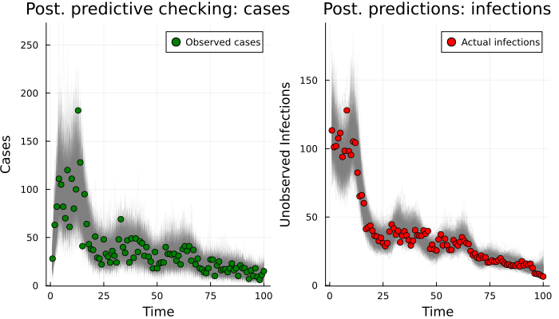

```julia
let
    post_check_mdl = fix(full_epi_aware_mdl, (rw_init = 0.0,))
    post_check_y_t = mapreduce(hcat, generated_quantities(post_check_mdl, chn)) do gen
        gen.generated_y_t
    end

    predicted_I_t = mapreduce(hcat, generated_quantities(inference_mdl, chn)) do gen
        gen.I_t
    end

    p1 = plot(post_check_y_t, c = :grey, alpha = 0.05, lab = "")
    scatter!(p1, truth_data,
        lab = "Observed cases",
        xlabel = "Time",
        ylabel = "Cases",
        title = "Post. predictive checking: cases",
        ylims = (-0.5, maximum(truth_data) * 1.5),
        c = :green)

    p2 = plot(predicted_I_t, c = :grey, alpha = 0.05, lab = "")
    scatter!(p2, true_infections,
        lab = "Actual infections",
        xlabel = "Time",
        ylabel = "Unobserved Infections",
        title = "Post. predictions: infections",
        ylims = (-0.5, maximum(true_infections) * 1.5),
        c = :red)

    plot(p1, p2,
        layout = (1, 2),
        size = (700, 400))
end
```

As well as checking the posterior predictions for latent infections, we can also check how well inference recovered unknown parameters, such as the random walk variance or the cluster factor of the negative binomial observations.

```julia
let
    parameters_to_plot = (:σ²_RW, :neg_bin_cluster_factor)

    plts = map(parameters_to_plot) do name
        var_samples = chn[name] |> vec
        histogram(var_samples,
            bins = 50,
            norm = :pdf,
            lw = 0,
            fillalpha = 0.5,
            lab = "MCMC")
        vline!([getfield(random_epidemic, name)], lab = "True value")
        title!(string(name))
    end
    plot(plts..., layout = (2, 1))
end
```

[figure not shown]

## Reproductive number back-calculation

As mentioned at the top, we *don't* directly use the concept of reproductive numbers in this note. However, we can back-calculate the implied $\mathcal{R}(t)$ values, conditional on the specified generation interval being correct.

Here we spaghetti plot posterior sampled time-varying reproductive numbers against the actual.

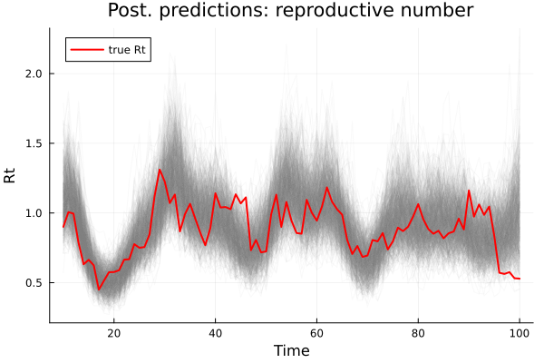

```julia
let
    n = epi_model.data.len_gen_int
    Rt_denom = [dot(reverse(epi_model.data.gen_int), true_infections[(t - n):(t - 1)])
                for t in (n + 1):length(true_infections)]
    true_Rt = true_infections[(n + 1):end] ./ Rt_denom

    predicted_Rt = mapreduce(hcat, generated_quantities(inference_mdl, chn)) do gen
        _It = gen.I_t
        _Rt_denom = [dot(reverse(epi_model.data.gen_int), _It[(t - n):(t - 1)])
                     for t in (n + 1):length(_It)]
        Rt = _It[(n + 1):end] ./ _Rt_denom
    end

    plt = plot((n + 1):time_horizon, predicted_Rt, c = :grey, alpha = 0.05, lab = "")
    plot!(plt, (n + 1):time_horizon, true_Rt,
        lab = "true Rt",
        xlabel = "Time",
        ylabel = "Rt",
        title = "Post. predictions: reproductive number",
        c = :red,
        lw = 2)
end
```